# Final Project

Pat is a popular beer maker and is trying to break into the ever-crowded space of brew-pubs. Pat wants to do this as efficiently as possible, though, so that a proper budget can be allocated to marketing.

Given the popularity of craft beers, Pat decides to focus initially on only a few beers: IPAs, Stouts, and Dunkels. Stouts and IPAs are brewed through the use of top-fermenting yeasts, while dunkels are brewed with bottom fermenting yeasts. Since the majority of beers are brewed with bottom-fermenting yeasts, bottom-fermenting yeasts are cheaper to produce.

## Beer Recipes

Each recipe makes 5 gallons of beer.

### IPA

12 pounds malts

6 ounces hops

1 ounce yeast

10 gallons water

### Stout

13 pounds malts

1 ounce hops

1 ounce yeast

10 gallons water

### Dunkel

10 pounds malts

1 ounce hops

1 ounce yeast

10 gallons water

## Resources and Selling Prices

Pat has purchased the following amounts of raw materials:

150 pounds of malts

3 pounds of hops

1 pound of yeast

1000 gallons of purified water

Pat also plans to sell each beer in 16 ounce glasses and will see each style for the following price:

Dunkel: $5.50

IPA: $6.50

Stout: $7.00

Pat needs to make some of every type of beer for this initial production run.

How much of each style should Pat produce to maximize revenue.

## The Beer Making Process

Pat knows that this is going to take some work, so there is a push to produce the beer in the most efficient way possible. Pat recognizes that additional purchases might be necessary to keep the total brewing time down.

Making beer can be broken down into the following steps:

1. Mash

A single 15.5 gallon mash tun can hold 37 pounds of grain and 12 gallons of water. The average mash takes 60 minutes, with a standard deviation of 15 minutes.

2. Lautering

Lautering is removing the sweet liquid from the mash and takes on average 45 minutes with a standard deviation of 10 minutes.

3. Boiling

Stronger beers generally take longer to boil, with dunkels needing 60 minutes, IPAs needing 65 minutes, and stouts taking 70 minutes.

4. Fermentation

Lagers generally take a long time to ferment, with the average being 23 days with a standard deviation of 2 days. Ales typically take less time and will be fermented on average after 14 days, with a standard deviation of 1 day.

5. Maturation

Lagers take between 5 and 9 days to mature, IPA take between 14 and 21 days to mature, and stouts can take between 21 and 28 days.

Currently, Pat has enough tuns (i.e., tanks) to make 1 batch of beer at a time. Given the optimum style mix, how long would it take Pat to prepare the beer. What can Pat do to improve his process?

## Travel Time

Pat needs to get an advertisement plan out. Pat plans to go to several cities and drop fliers off with friends, but the travel time needs to be minimized.

There are coordinates for the places Pat needs to visit:

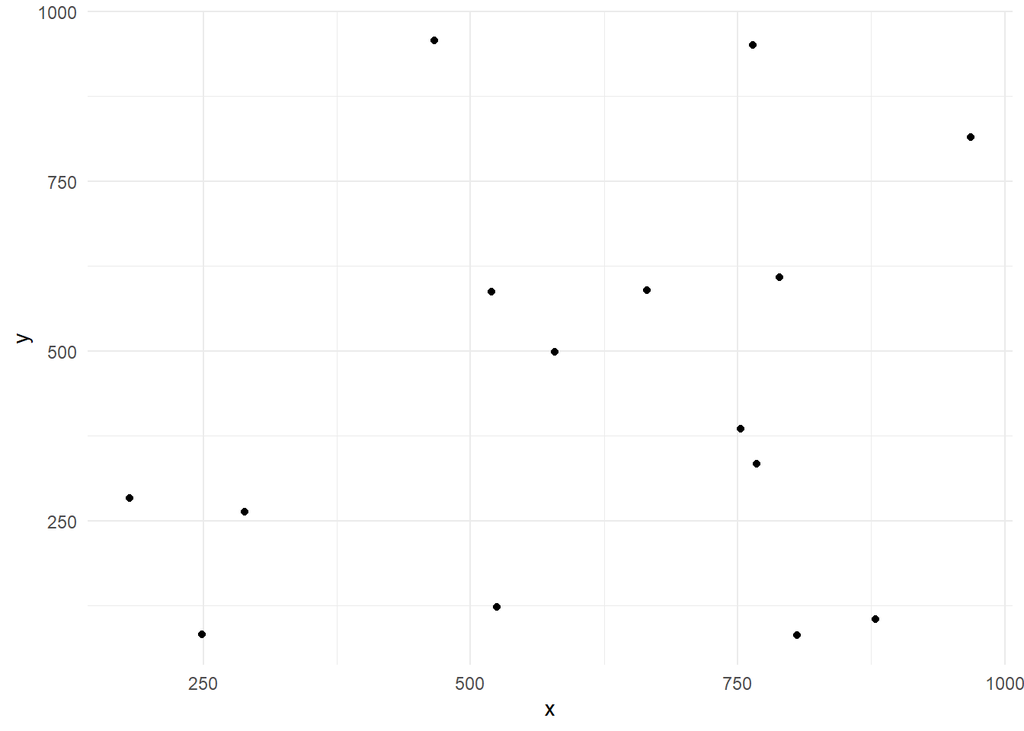

```r
library(ggplot2)

businessLocations <- read.csv("http://www.nd.edu/~sberry5/data/warehouseLocations.csv")

ggplot(businessLocations, aes(x, y)) +
  geom_point() +
  theme_minimal()
```

Calculate the distances between each city and propose a travel plan for Pat.